# Agence Nissa Bank

MARIANO ALBUQUERQUE, Melissa

## Vérification du territoire (QPV)

Oui, l’agence est dans un QPV, selon le site https://sig.ville.gouv.fr/.

[figure not shown]

Les besoins des clients :

- **pas chers :** les gens ont besoin de trucs simples. Par exemple, une carte bancaire de base et un compte sans frais compliqués (ou gratuits).
- **petits crédits :** les petits commerçants du quartier ont besoin des micro-crédits pour rester ouvert.
- **épargne simple :** pour mettre de l’argent de côté, ils veulent des choses faciles comme le Livret A.
- **aide et conseils :** c’est important de parler avec eux et de donner des conseils de gestion simples. Pour éviter les gros problèmes d’argent et les dettes.

## Segmentation de la cientèle

Quand on sais déjà la quantité de groupes/clusters on veux, la methode pour travailler c’est le Clustering K-means.

```r
library(tidyverse)
library(cluster)
library(factoextra)
library(ggplot2)
library(dendextend)
```

```r
dados <- read.csv("agence_nissa_bank.csv", stringsAsFactors = TRUE)
```

[figure not shown]

```r
str(dados)
```

```
## 'data.frame':    5012 obs. of  9 variables:
##  $ ID.Client       : Factor w/ 5012 levels "CL100001","CL100002",..: 1 2 3 4 5 6 7 8 9 10 ...
##  $ Nom             : Factor w/ 400 levels "Adam","Albert",..: 149 304 276 360 56 345 393 193 124 105 ...
##  $ Prénom          : Factor w/ 215 levels "Adélaïde","Adèle",..: 122 76 6 60 207 109 214 94 100 2 ...
##  $ Âge             : int  19 46 37 21 23 23 61 55 51 36 ...
##  $ Situation       : Factor w/ 13 levels "Agent d'entretien",..: 8 9 5 6 5 6 3 6 7 4 ...
##  $ Revenu.mensuel..: num  923 2722 1480 1152 1621 ...
##  $ Produits.détenus: Factor w/ 5 levels "Compte courant",..: 3 5 1 5 4 3 4 4 3 1 ...
##  $ Crédit.en.cours : Factor w/ 5 levels "Aucun crédit",..: 1 5 5 2 4 5 5 5 1 3 ...
##  $ Épargne..       : num  671 1538 2279 1086 1162 ...
```

```r
summary(dados)
```

```
##     ID.Client          Nom            Prénom          Âge
##  CL100001:   1   Rossi   :  25   Suzanne :  53   Min.   :18.00
##  CL100002:   1   Sanchez :  23   Margot  :  45   1st Qu.:28.00
##  CL100003:   1   Dupuis  :  22   Michelle:  45   Median :40.00
##  CL100004:   1   Legendre:  22   Nathalie:  45   Mean   :41.36
##  CL100005:   1   Vallée  :  22   Aurélie :  37   3rd Qu.:53.00
##  CL100006:   1   Da Costa:  21   Victoire:  35   Max.   :85.00
##  (Other) :5006   (Other) :4877   (Other) :4752
##             Situation    Revenu.mensuel..
##  Employé         :1196   Min.   :   0.17
##  Employé précaire: 822   1st Qu.:1043.55
##  Étudiant        : 622   Median :1477.33
##  Sans emploi     : 526   Mean   :1439.67
##  Retraité        : 357   3rd Qu.:1860.75
##  Artisan         : 346   Max.   :2989.13
##  (Other)         :1143
##                                    Produits.détenus            Crédit.en.cours
##  Compte courant                            :1235    Aucun crédit       :1304
##  Compte courant + Assurance habitation     : 664    Crédit consommation: 933
##  Compte courant + Carte bancaire           :1261    Découvert autorisé :1005
##  Compte courant + Carte bancaire + Livret A: 606    Microcrédit        :1071
##  Compte courant + Livret A                 :1246    Prêt automobile    : 699
##
##
##    Épargne..
##  Min.   :   0.24
##  1st Qu.: 325.44
##  Median : 777.55
##  Mean   :1172.95
##  3rd Qu.:1686.01
##  Max.   :6999.30
##
```

```r
names(dados)
```

```
## [1] "ID.Client"        "Nom"              "Prénom"           "Âge"
## [5] "Situation"        "Revenu.mensuel.." "Produits.détenus" "Crédit.en.cours"
## [9] "Épargne.."
```

```r
dados_modif <- rename(dados,
                id_client = "ID.Client",
                nom = "Nom",
                prenom = "Prénom",
                age = "Âge",
                situation = "Situation",
                revenu_mensuel = "Revenu.mensuel..",
                produits_detenus = "Produits.détenus",
                credit_en_cours = "Crédit.en.cours",
                epargne = "Épargne..")
```

```r
# removendo pelas posições (indica para dropar da coluna 1 até a coluna 3)
dados_modif <- select(dados_modif, -c(1:3))
```

```r
# cria um novo dataframe apenas com as colunas numéricas (age, revenu_mensuel, epargne)
dados_numericos <- select(dados_modif, where(is.numeric))

# cria um novo dataframe apenas com os fatores/categóricas (situation, credit_en_cours, etc.)
dados_categoricos <- select(dados_modif, where(is.factor))
```

1. Calcular a Matriz de Correlação Rode a função cor() passando o seu dataframe numérico. O argumento use = “complete.obs” serve para o R ignorar linhas que tenham algum valor vazio (NA), evitando que o resultado dê erro.

```r
# Calcula a correlação de Pearson entre todas as colunas numéricas
matriz_cor <- cor(dados_numericos, use = "complete.obs")

# Exibe a matriz de números no console
print(matriz_cor)
```

```
##                      age revenu_mensuel   epargne
## age            1.0000000      0.2606446 0.1401195
## revenu_mensuel 0.2606446      1.0000000 0.6753114
## epargne        0.1401195      0.6753114 1.0000000
```

Embora a renda e a poupança apresentem uma correlação linear positiva moderada/forte ($\rho = 0.675$), optou-se por manter ambas na segmentação. No algoritmo de agrupamento K-means, elas representam dimensões distintas do comportamento do cliente (capacidade de ganho versus acumulação de patrimônio). A eventual redundância geométrica é controlada pela aplicação da normalização Min-Max, preservando a variância essencial de cada perfil sem os problemas de inversão de matriz típicos de uma regressão linear.

```r
# Teste 1: Profissão vs Produtos
qui_1 <- chisq.test(table(dados_modif$situation, dados_modif$produits_detenus))

# Teste 2: Profissão vs Crédito
qui_2 <- chisq.test(table(dados_modif$situation, dados_modif$credit_en_cours))

# Teste 3: Produtos vs Crédito
qui_3 <- chisq.test(table(dados_modif$produits_detenus, dados_modif$credit_en_cours))

# Exibe os p-values para o seu relatório
cat("=== RESULTADOS DOS TESTES QUI-QUADRADO (P-VALUES) ===\n")
```

```
## === RESULTADOS DOS TESTES QUI-QUADRADO (P-VALUES) ===
```

```r
cat("Situação vs Produtos: ", qui_1$p.value, "\n")
```

```
## Situação vs Produtos:  1.197069e-113
```

```r
cat("Situação vs Crédito:  ", qui_2$p.value, "\n")
```

```
## Situação vs Crédito:   8.230077e-50
```

```r
cat("Produtos vs Crédito:  ", qui_3$p.value, "\n")
```

```
## Produtos vs Crédito:   7.634666e-14
```

Os testes provam que as três variáveis são fortemente dependentes entre si.

O comportamento dos clientes da Nissa Bank não é aleatório. A situação profissional de um cliente está diretamente amarrada ao tipo de produto que ele consome e ao tipo de crédito que ele pega. Da mesma forma, o produto que ele tem dita o tipo de crédito que ele utiliza.

Esses resultados dão a validação científica perfeita para a escolha das suas features.Se um p-value desses tivesse dado maior que 0,05, significaria que a variável era “ruído” (irrelevante) e criar dummies para ela só serviria para deixar o algoritmo $K$-means confuso e lento.Como todas mostraram associações gigantescas, você acabou de provar que deixar as três variáveis na base e transformá-las em dummies é o caminho correto, pois cada uma delas carrega um padrão de comportamento único e crucial para desenhar os 4 perfis de clientes da agência.

```r
preparar_dados <- function(dataset) {
  matriz_dummies <- model.matrix(~ . - 1, data = dataset)
  df_dummies <- as.data.frame(matriz_dummies)

  normalizar_min_max <- function(x) {
    if (max(x) - min(x) == 0) return(x)
    return((x - min(x)) / (max(x) - min(x)))
  }

  dados_normalizados <- as.data.frame(lapply(df_dummies, normalizar_min_max))
  return(dados_normalizados)
}
```

```r
pronto_tudo <- preparar_dados(dados_modif)
```

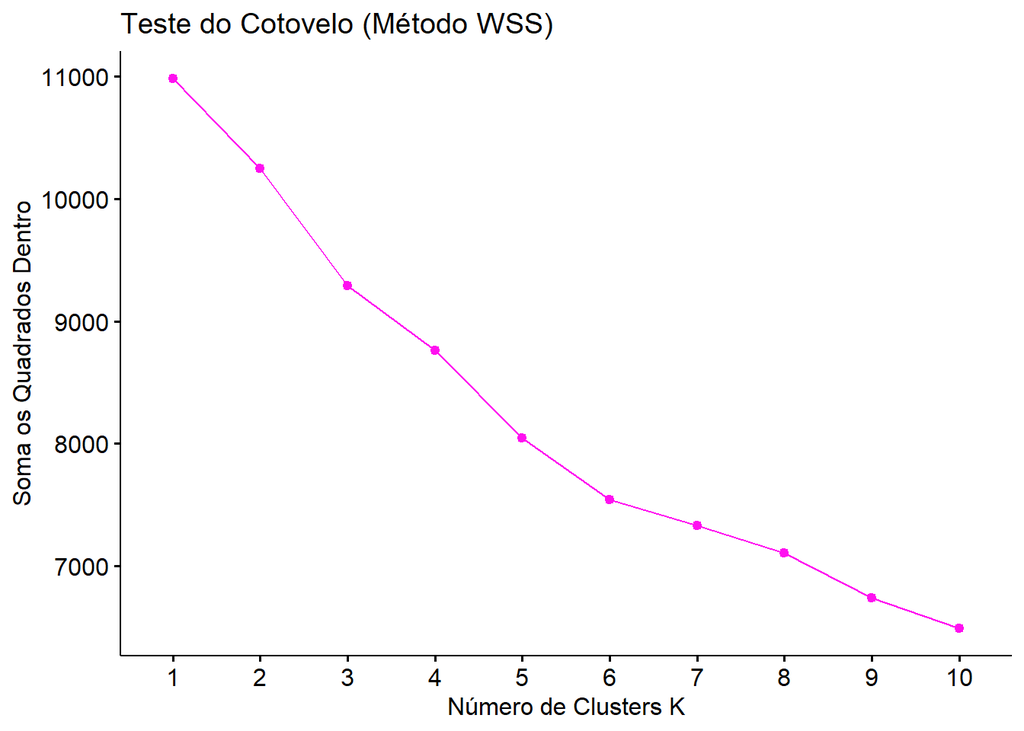

```r
# Gráfico do Cotovelo (Rosa Neon)
fviz_nbclust(pronto_tudo, kmeans, method = "wss", linecolor = "#FF10F0") +
  labs(title = "Teste do Cotovelo (Método WSS)", x = "Número de Clusters K", y = "Soma os Quadrados Dentro")
```

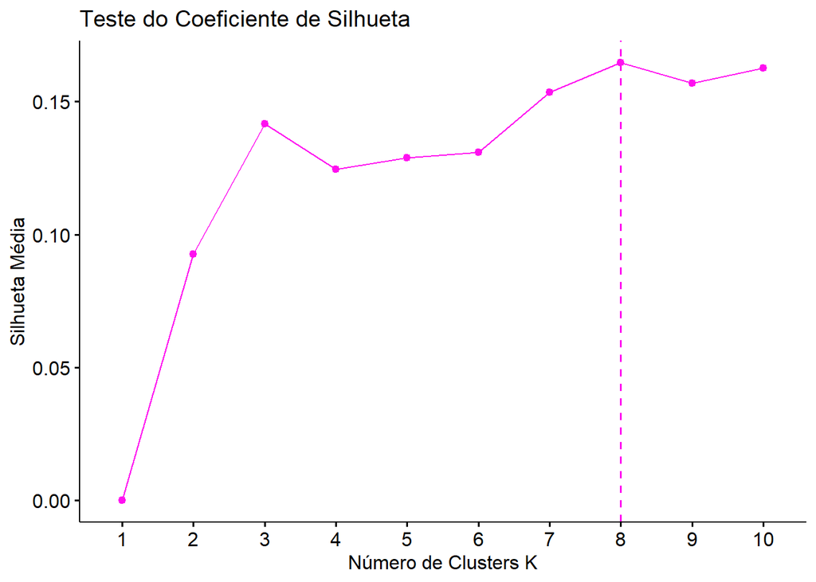

```r
# Gráfico da Silhueta Média (Verde Neon)
fviz_nbclust(pronto_tudo, kmeans, method = "silhouette", linecolor = "#FF10F0") +
  labs(title = "Teste do Coeficiente de Silhueta", x = "Número de Clusters K", y = "Silhueta Média")
```

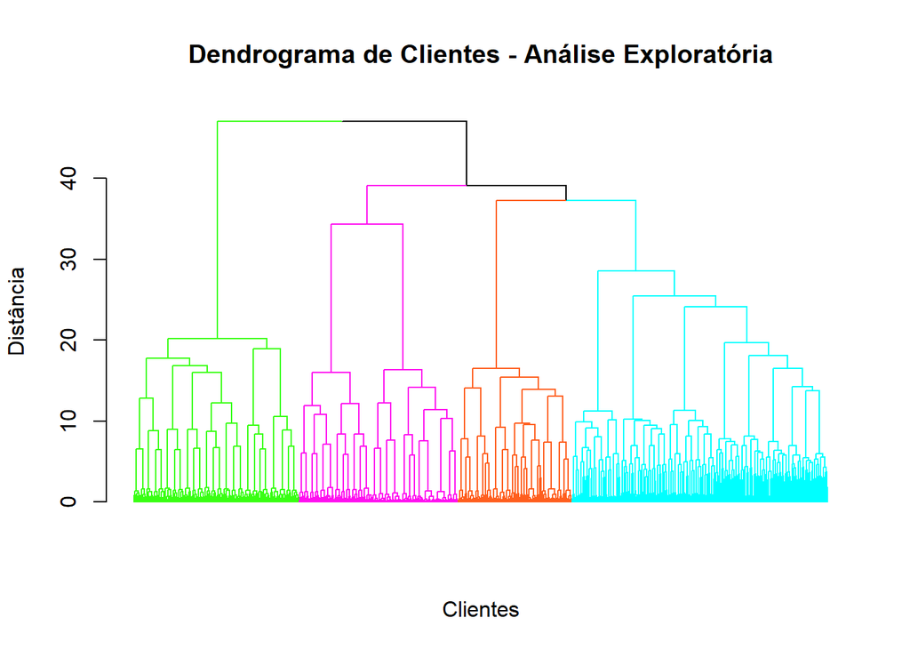

```r
# 1. Calcula a matriz de distância geométrica
matriz_distancia <- dist(pronto_tudo, method = "euclidean")

# 2. Executa o agrupamento hierárquico (Método de Ward)
modelo_hierarquico <- hclust(matriz_distancia, method = "ward.D2")

# 3. Converte o resultado para um objeto dendrograma
dend <- as.dendrogram(modelo_hierarquico)

# 4. Colore as ramificações dos 4 grupos com as cores neon (processamento otimizado)
dend <- color_branches(dend, k = 4, col = c("#39FF14", "#FF10F0", "#FF5F1F", "#00FFFF"))

# 5. Plota o dendrograma modificado removendo os rótulos individuais das folhas (leaflab = "none")
plot(dend, leaflab = "none", main = "Dendrograma de Clientes - Análise Exploratória",
     xlab = "Clientes", ylab = "Distância")
```

```r
# ==============================================================================
# EXECUÇÃO DOS DOIS MODELOS EM PARALELO (4 E 8 CLUSTERS)
# ==============================================================================

# Garante que os resultados sejam sempre os mesmos ao rodar
set.seed(123)

# Modelo A: A preferência do negócio (4 Clusters)
modelo_k4 <- kmeans(pronto_tudo, centers = 4, nstart = 25)
dados_modif$cluster_4 <- as.factor(modelo_k4$cluster)

# Modelo B: O ideal matemático (8 Clusters)
modelo_k8 <- kmeans(pronto_tudo, centers = 8, nstart = 25)
dados_modif$cluster_8 <- as.factor(modelo_k8$cluster)

# ==============================================================================
# COMPARAÇÃO DO TAMANHO DOS GRUPOS
# ==============================================================================

cat("=== DISTRIBUIÇÃO DOS CLIENTES EM 4 CLUSTERS ===\n")
```

```
## === DISTRIBUIÇÃO DOS CLIENTES EM 4 CLUSTERS ===
```

```r
print(table(dados_modif$cluster_4))
```

```
##
##    1    2    3    4
## 1196 1391 1402 1023
```

```r
cat("\n")
```

```r
cat("=== DISTRIBUIÇÃO DOS CLIENTES EM 8 CLUSTERS ===\n")
```

```
## === DISTRIBUIÇÃO DOS CLIENTES EM 8 CLUSTERS ===
```

```r
print(table(dados_modif$cluster_8))
```

```
##
##   1   2   3   4   5   6   7   8
## 722 622 616 526 468 872 489 697
```

```r
# ==============================================================================
# PERFILAMENTO DOS 4 CLUSTERS (K = 4)
# ==============================================================================
cat("\n#########################################################\n")
```

```
##
## #########################################################
```

```r
cat("                CARACTERÍSTICAS DOS 4 CLUSTERS             \n")
```

```
##                 CARACTERÍSTICAS DOS 4 CLUSTERS
```

```r
cat("#########################################################\n\n")
```

```
## #########################################################
```

```r
# 1. Numéricas (Mediana) para 4 clusters
perfil_num_k4 <- aggregate(cbind(age, revenu_mensuel, epargne) ~ cluster_4, data = dados_modif, FUN = median)
perfil_num_k4[, 2:4] <- round(perfil_num_k4[, 2:4], 2)
print("=== NUMÉRICAS (Mediana) ===")
```

```
## [1] "=== NUMÉRICAS (Mediana) ==="
```

```r
print(perfil_num_k4)
```

```
##   cluster_4 age revenu_mensuel epargne
## 1         1  41        1884.72 1680.95
## 2         2  33         975.68  382.61
## 3         3  44        1595.93  972.40
## 4         4  38        1152.70  523.88
```

```r
# 2. Categóricas (Proporção) para 4 clusters
cat("\n=== CATEGÓRICAS: Situação Profissional (%) ===\n")
```

```
##
## === CATEGÓRICAS: Situação Profissional (%) ===
```

```r
print(round(prop.table(table(dados_modif$cluster_4, dados_modif$situation), margin = 1), 4) * 100)
```

```
##
##     Agent d'entretien Aide à domicile Artisan Caissier Employé Employé précaire
##   1              0.00            0.00    0.00     0.00  100.00             0.00
##   2              1.44            2.95    5.97     2.37    0.00            14.74
##   3              3.42            6.85   12.77     6.70    0.00            27.10
##   4              1.96            4.30    8.21     2.74    0.00            23.17
##
##     Entrepreneur local Étudiant Fonctionnaire Livreur Retraité Sans emploi
##   1               0.00     0.00          0.00    0.00     0.00        0.00
##   2               2.59    30.98          4.39    1.80     5.97       25.09
##   3               8.27     0.00         15.05    3.28    12.34        0.00
##   4               3.13    18.67          6.06    2.54     9.87       17.30
##
##     Serveur
##   1    0.00
##   2    1.73
##   3    4.21
##   4    2.05
```

```r
cat("\n=== CATEGÓRICAS: Produtos Detidos (%) ===\n")
```

```
##
## === CATEGÓRICAS: Produtos Detidos (%) ===
```

```r
print(round(prop.table(table(dados_modif$cluster_4, dados_modif$produits_detenus), margin = 1), 4) * 100)
```

```
##
##     Compte courant Compte courant + Assurance habitation
##   1          20.32                                 22.24
##   2          27.46                                  0.00
##   3          43.51                                 28.39
##   4           0.00                                  0.00
##
##     Compte courant + Carte bancaire Compte courant + Carte bancaire + Livret A
##   1                           21.07                                      17.73
##   2                           72.54                                       0.00
##   3                            0.00                                      28.10
##   4                            0.00                                       0.00
##
##     Compte courant + Livret A
##   1                     18.65
##   2                      0.00
##   3                      0.00
##   4                    100.00
```

```r
cat("\n=== CATEGÓRICAS: Crédito em Curso (%) ===\n")
```

```
##
## === CATEGÓRICAS: Crédito em Curso (%) ===
```

```r
print(round(prop.table(table(dados_modif$cluster_4, dados_modif$credit_en_cours), margin = 1), 4) * 100)
```

```
##
##     Aucun crédit Crédit consommation Découvert autorisé Microcrédit
##   1        20.48               17.39              19.40       21.91
##   2        31.42               20.13              21.50       20.27
##   3        22.61               18.26              19.19       21.26
##   4        29.81               18.48              20.04       22.39
##
##     Prêt automobile
##   1           20.82
##   2            6.69
##   3           18.69
##   4            9.29
```

```r
# ==============================================================================
# PERFILAMENTO DOS 8 CLUSTERS (K = 8)
# ==============================================================================
cat("\n\n#########################################################\n")
```

```
##
##
## #########################################################
```

```r
cat("                CARACTERÍSTICAS DOS 8 CLUSTERS             \n")
```

```
##                 CARACTERÍSTICAS DOS 8 CLUSTERS
```

```r
cat("#########################################################\n\n")
```

```
## #########################################################
```

```r
# 1. Numéricas (Mediana) para 8 clusters
perfil_num_k8 <- aggregate(cbind(age, revenu_mensuel, epargne) ~ cluster_8, data = dados_modif, FUN = median)
perfil_num_k8[, 2:4] <- round(perfil_num_k8[, 2:4], 2)
print("=== NUMÉRICAS (Mediana) ===")
```

```
## [1] "=== NUMÉRICAS (Mediana) ==="
```

```r
print(perfil_num_k8)
```

```
##   cluster_8 age revenu_mensuel epargne
## 1         1  41        1866.90 1658.14
## 2         2  22         583.44  384.96
## 3         3  44        1714.72 1216.12
## 4         4  40         571.76  181.16
## 5         5  45        1780.71 1439.23
## 6         6  47        1711.84 1290.70
## 7         7  42        1578.65  971.88
## 8         8  41        1280.82  575.00
```

```r
# 2. Categóricas (Proporção) para 8 clusters
cat("\n=== CATEGÓRICAS: Situação Profissional (%) ===\n")
```

```
##
## === CATEGÓRICAS: Situação Profissional (%) ===
```

```r
print(round(prop.table(table(dados_modif$cluster_8, dados_modif$situation), margin = 1), 4) * 100)
```

```
##
##     Agent d'entretien Aide à domicile Artisan Caissier Employé Employé précaire
##   1              0.00            0.00    0.00     0.00  100.00             0.00
##   2              0.00            0.00    0.00     0.00    0.00             0.00
##   3              3.25            6.66   13.47     5.36   34.09             0.00
##   4              0.00            0.00    0.00     0.00    0.00             0.00
##   5              2.14            5.34   11.11     3.63   44.44             0.00
##   6              5.28            9.40   17.20     8.49    0.00             0.00
##   7              2.45            6.75   12.47     6.34   11.45            25.56
##   8              0.00            0.00    0.00     0.00    0.00           100.00
##
##     Entrepreneur local Étudiant Fonctionnaire Livreur Retraité Sans emploi
##   1               0.00     0.00          0.00    0.00     0.00        0.00
##   2               0.00   100.00          0.00    0.00     0.00        0.00
##   3               5.84     0.00          9.90    4.06    13.47        0.00
##   4               0.00     0.00          0.00    0.00     0.00      100.00
##   5               5.56     0.00         11.32    3.63    10.26        0.00
##   6              10.21     0.00         19.15    4.70    20.07        0.00
##   7               6.75     0.00         10.84    2.86    10.43        0.00
##   8               0.00     0.00          0.00    0.00     0.00        0.00
##
##     Serveur
##   1    0.00
##   2    0.00
##   3    3.90
##   4    0.00
##   5    2.56
##   6    5.50
##   7    4.09
##   8    0.00
```

```r
cat("\n=== CATEGÓRICAS: Produtos Detidos (%) ===\n")
```

```
##
## === CATEGÓRICAS: Produtos Detidos (%) ===
```

```r
print(round(prop.table(table(dados_modif$cluster_8, dados_modif$produits_detenus), margin = 1), 4) * 100)
```

```
##
##     Compte courant Compte courant + Assurance habitation
##   1          26.87                                 31.16
##   2          34.08                                  0.00
##   3           0.00                                  0.00
##   4          32.32                                  0.00
##   5          24.79                                 21.58
##   6          26.95                                 23.17
##   7          26.99                                 17.59
##   8          25.25                                  7.17
##
##     Compte courant + Carte bancaire Compte courant + Carte bancaire + Livret A
##   1                            0.00                                      24.10
##   2                           35.21                                       0.00
##   3                          100.00                                       0.00
##   4                           34.03                                       0.00
##   5                            8.97                                      19.66
##   6                            0.00                                      21.22
##   7                            0.00                                      16.36
##   8                           29.41                                      10.76
##
##     Compte courant + Livret A
##   1                     17.87
##   2                     30.71
##   3                      0.00
##   4                     33.65
##   5                     25.00
##   6                     28.67
##   7                     39.06
##   8                     27.40
```

```r
cat("\n=== CATEGÓRICAS: Crédito em Curso (%) ===\n")
```

```
##
## === CATEGÓRICAS: Crédito em Curso (%) ===
```

```r
print(round(prop.table(table(dados_modif$cluster_8, dados_modif$credit_en_cours), margin = 1), 4) * 100)
```

```
##
##     Aucun crédit Crédit consommation Découvert autorisé Microcrédit
##   1        27.29                0.00              25.48       20.36
##   2        38.91               19.13              21.22       20.74
##   3        23.21               12.34              20.45       23.38
##   4        34.79               21.10              21.86       22.24
##   5         0.00              100.00               0.00        0.00
##   6        36.70                0.00              32.00        0.00
##   7         0.00                0.00               0.00      100.00
##   8        31.42               22.81              24.25        6.46
##
##     Prêt automobile
##   1           26.87
##   2            0.00
##   3           20.62
##   4            0.00
##   5            0.00
##   6           31.31
##   7            0.00
##   8           15.06
```

analise por cluster

```r
# ==============================================================================
# RESUMO INDIVIDUALIZADO POR PERSONA (K = 4)
# ==============================================================================

for (i in 1:4) {
  cat("\n==================================================================\n")
  cat(paste("                      PERFIL DA PERSONA", i, "\n"))
  cat("==================================================================\n")

  # Isola os dados apenas do cluster iterado no momento
  dados_cluster <- subset(dados_modif, cluster_4 == i)

  # Calcula o tamanho do grupo em relação ao total da agência
  tamanho <- nrow(dados_cluster)
  proporcao_base <- round((tamanho / nrow(dados_modif)) * 100, 2)
  cat(paste("Volume de Clientes: ", tamanho, " (", proporcao_base, "% da base total)\n\n", sep = ""))

  # Indicadores Numéricos (Mediana)
  cat("--- Indicadores Numéricos ---\n")
  cat("• Idade:           ", median(dados_cluster$age), "anos\n")
  cat("• Renda Mensal:     €", round(median(dados_cluster$revenu_mensuel), 2), "\n")
  cat("• Poupança:         €", round(median(dados_cluster$epargne), 2), "\n\n")

  # Indicadores Categóricos (Exibe apenas as categorias presentes no grupo > 0%)
  cat("--- Comportamento Categórico Interno ---\n")

  cat("\n> Situação Profissional (%):\n")
  freq_sit <- round(prop.table(table(dados_cluster$situation)) * 100, 2)
  print(freq_sit[freq_sit > 0])

  cat("\n> Produtos Detidos (%):\n")
  freq_prod <- round(prop.table(table(dados_cluster$produits_detenus)) * 100, 2)
  print(freq_prod[freq_prod > 0])

  cat("\n> Crédito em Curso (%):\n")
  freq_cred <- round(prop.table(table(dados_cluster$credit_en_cours)) * 100, 2)
  print(freq_cred[freq_cred > 0])
}
```

```
##
## ==================================================================
##                       PERFIL DA PERSONA 1
## ==================================================================
## Volume de Clientes: 1196 (23.86% da base total)
##
## --- Indicadores Numéricos ---
## • Idade:            41 anos
## • Renda Mensal:     € 1884.72
## • Poupança:         € 1680.95
##
## --- Comportamento Categórico Interno ---
##
## > Situação Profissional (%):
## Employé
##     100
##
## > Produtos Detidos (%):
##
##                             Compte courant
##                                      20.32
##      Compte courant + Assurance habitation
##                                      22.24
##            Compte courant + Carte bancaire
##                                      21.07
## Compte courant + Carte bancaire + Livret A
##                                      17.73
##                  Compte courant + Livret A
##                                      18.65
##
## > Crédito em Curso (%):
##
##        Aucun crédit Crédit consommation  Découvert autorisé         Microcrédit
##               20.48               17.39               19.40               21.91
##     Prêt automobile
##               20.82
##
## ==================================================================
##                       PERFIL DA PERSONA 2
## ==================================================================
```

[output cut: 83 more lines]

```
##   Employé précaire Entrepreneur local           Étudiant      Fonctionnaire
##              23.17               3.13              18.67               6.06
##            Livreur           Retraité        Sans emploi            Serveur
##               2.54               9.87              17.30               2.05
##
## > Produtos Detidos (%):
## Compte courant + Livret A
##                       100
##
## > Crédito em Curso (%):
##
##        Aucun crédit Crédit consommation  Découvert autorisé         Microcrédit
##               29.81               18.48               20.04               22.39
##     Prêt automobile
##                9.29
```

```r
# ==============================================================================
# ANÁLISE DE AFINIDADE (LIFT) PARA CROSS-SELLING E UP-SELLING
# ==============================================================================

cat("\n#########################################################\n")
```

```
##
## #########################################################
```

```r
cat("        CÁLCULO DE LIFT (AFINIDADE) POR CLUSTER            \n")
```

```
##         CÁLCULO DE LIFT (AFINIDADE) POR CLUSTER
```

```r
cat("#########################################################\n")
```

```
## #########################################################
```

```r
# 1. Calcula a proporção de cada produto e crédito na base TOTAL da agência
prop_base_produtos <- prop.table(table(dados_modif$produits_detenus))
prop_base_credito <- prop.table(table(dados_modif$credit_en_cours))

# 2. Loop para calcular e imprimir o Lift para cada um dos 4 clusters
for (i in 1:4) {
  cat("\n==================================================================\n")
  cat(paste("                      LIFT - CLUSTER", i, "\n"))
  cat("==================================================================\n")

  # Filtra os dados apenas para o cluster atual
  dados_cluster <- subset(dados_modif, cluster_4 == i)

  # Calcula a proporção de produtos e créditos dentro do cluster
  prop_cluster_produtos <- prop.table(table(dados_cluster$produits_detenus))
  prop_cluster_credito <- prop.table(table(dados_cluster$credit_en_cours))

  # Calcula o Lift (Proporção no Cluster dividida pela Proporção na Base Geral)
  lift_produtos <- prop_cluster_produtos / prop_base_produtos
  lift_credito <- prop_cluster_credito / prop_base_credito

  # Exibe os resultados separados entre o que deve ser ofertado e o que deve ser evitado
  cat("\n> PRODUTOS PARA CROSS-SELLING (Alta Afinidade | Lift > 1):\n")
  produtos_fortes <- round(lift_produtos[lift_produtos > 1], 2)
  if(length(produtos_fortes) > 0) print(sort(produtos_fortes, decreasing = TRUE)) else cat("Nenhum produto em destaque.\n")

  cat("\n> PRODUTOS PARA EVITAR (Baixa Afinidade | Lift < 1):\n")
  produtos_fracos <- round(lift_produtos[lift_produtos < 1], 2)
  if(length(produtos_fracos) > 0) print(sort(produtos_fracos)) else cat("Nenhum produto fraco.\n")

  cat("\n------------------------------------------------------------------\n")

  cat("> CRÉDITOS PARA CROSS-SELLING (Alta Afinidade | Lift > 1):\n")
  creditos_fortes <- round(lift_credito[lift_credito > 1], 2)
  if(length(creditos_fortes) > 0) print(sort(creditos_fortes, decreasing = TRUE)) else cat("Nenhum crédito em destaque.\n")

  cat("\n> CRÉDITOS PARA EVITAR (Baixa Afinidade | Lift < 1):\n")
  creditos_fracos <- round(lift_credito[lift_credito < 1], 2)
  if(length(creditos_fracos) > 0) print(sort(creditos_fracos)) else cat("Nenhum crédito fraco.\n")
}
```

```
##
## ==================================================================
##                       LIFT - CLUSTER 1
## ==================================================================
##
## > PRODUTOS PARA CROSS-SELLING (Alta Afinidade | Lift > 1):
##
##      Compte courant + Assurance habitation
##                                       1.68
## Compte courant + Carte bancaire + Livret A
##                                       1.47
##
## > PRODUTOS PARA EVITAR (Baixa Afinidade | Lift < 1):
##
##       Compte courant + Livret A                  Compte courant
##                            0.75                            0.82
## Compte courant + Carte bancaire
##                            0.84
##
## ------------------------------------------------------------------
## > CRÉDITOS PARA CROSS-SELLING (Alta Afinidade | Lift > 1):
##
## Prêt automobile     Microcrédit
##            1.49            1.03
##
## > CRÉDITOS PARA EVITAR (Baixa Afinidade | Lift < 1):
##
##        Aucun crédit Crédit consommation  Découvert autorisé
##                0.79                0.93                0.97
##
## ==================================================================
##                       LIFT - CLUSTER 2
## ==================================================================
##
## > PRODUTOS PARA CROSS-SELLING (Alta Afinidade | Lift > 1):
##
## Compte courant + Carte bancaire                  Compte courant
##                            2.88                            1.11
##
## > PRODUTOS PARA EVITAR (Baixa Afinidade | Lift < 1):
```

[output cut: 61 more lines]

```
##            Compte courant + Carte bancaire
##                                          0
## Compte courant + Carte bancaire + Livret A
##                                          0
##
## ------------------------------------------------------------------
## > CRÉDITOS PARA CROSS-SELLING (Alta Afinidade | Lift > 1):
##
## Aucun crédit  Microcrédit
##         1.15         1.05
##
## > CRÉDITOS PARA EVITAR (Baixa Afinidade | Lift < 1):
##
##     Prêt automobile Crédit consommation  Découvert autorisé
##                0.67                0.99                1.00
```

## Arguments pour un bon système de gestion de données commerciales

Donnez 3 arguments solides.

1. Segmentação Precisa e Aumento de Vendas (Cross-selling) Um sistema de gestão de dados estruturado e limpo é o pré-requisito fundamental para aplicar algoritmos de inteligência artificial, como a clusterização K-means que você acabou de executar. Ele permite cruzar histórico de transações com dados demográficos para calcular a afinidade de produtos (Lift). Sem esse sistema, o banco faria ofertas genéricas; com ele, a agência consegue direcionar a campanha de microcrédito exatamente para a persona com maior probabilidade de conversão.
2. Eficiência Operacional e Mitigação de Riscos de Crédito A integração de dados comerciais elimina silos de informação dentro da agência. Quando o gerente acessa o perfil de um cliente, ele vê o quadro completo em tempo real (idade, renda, poupança e créditos ativos). Isso não apenas acelera o tempo de atendimento presencial, mas fornece uma base matemática segura para a análise de risco, evitando a concessão de limite de cheque especial ou novos empréstimos para perfis com alta probabilidade de inadimplência.
3. Conformidade Regulatória e Segurança da Informação (RGPD) Operando na França, a gestão rigorosa de dados de clientes é uma exigência legal imposta pelo Regulamento Geral sobre a Proteção de Dados (RGPD). Um sistema comercial sólido garante que informações financeiras sensíveis sejam armazenadas com criptografia adequada e controle de acesso. Além disso, permite gerenciar o consentimento dos clientes e executar rapidamente solicitações de direito ao esquecimento ou portabilidade de dados, blindando a agência contra vazamentos e multas severas.